# CARPS Reproducibility Report

```r
articleID <- "10-7-2014_PS" # insert the article ID code here e.g., "10-3-2015_PS"
reportType <- 'pilot'
pilotNames <- "Jaclyn Schwartz, Drew Tysen Dauer, Erik Santoro" # insert the pilot's name here e.g., "Tom Hardwicke". If there are multiple pilots enter both names in a character string e.g., "Tom Hardwicke, Bob Dylan"
copilotNames <- "" # insert the co-pilot's name here e.g., "Michael Frank". If there are multiple co-pilots enter both names in a character string e.g., "Tom Hardwicke, Bob Dylan"
pilotTTC <- 420 # insert the pilot's estimated time to complete (in minutes, fine to approximate) e.g., 120
copilotTTC <- NA # insert the co- pilot's estimated time to complete (in minutes, fine to approximate) e.g., 120
pilotStartDate <- as.Date("10/26/2017", format = "%m/%d/%y") # insert the pilot's start date in US format e.g., as.Date("01/25/18", format = "%m/%d/%y")
copilotStartDate <- as.Date("", format = "%m/%d/%y") # insert the co-pilot's start date in US format e.g., as.Date("01/25/18", format = "%m/%d/%y")
completionDate <- as.Date("", format = "%m/%d/%y") # copilot insert the date of final report completion (after any necessary rounds of author assistance) in US format e.g., as.Date("01/25/18", format = "%m/%d/%y")
```

#### Methods summary:

[The point of Gilead & Liberman’s (2014) “Study 1” is to test if activating “caregiving motivation” would strengthen a bias against out-groups. The authors recruited 300 participants (all Jewish mothers) to participate in an online study. N = 300 was deterimined with 75 participants per condition. There were 4 condtions. However, 14 were excluded, leaving N of 286. The 4 conditions were based on 2 manipulations: *caregiving-salience manipulation* (with 2 groups: caregiving-salience group and no-caregiving-salience group) and *out-group threat manipulation* (with 2 groups: out-group-threat condition and natural-threat condition). Condition assignment was random and created by crossing the two caregiving-salience conditions with the two out-group-threat conditions. The DV of out-group bias was operationalized with an out-group bias questionnaire. The authors normalized the out-group bias scores, and then performed a factorial ANOVA with “caregiving (caregiving salience vs. no caregiving salience) and threat (out-group threat vs. natural threat) as IVs, and out-group bias as the DV.” After finding an interaction, simple effects analyses were performed.]

#### Target outcomes:

[The results showed a significant interaction between caregiving and threat, F(1, 282) = 4.220, p = .041, ηp2 = .014 (Fig. 1). Simple-effects analysis revealed that in the out-group-threat condition, participants who were primed for caregiving salience showed significantly higher levels of out-group bias (M = 0.851, SD = 0.528) than did the no-caregiving-salience group (M = 0.654, SD = 0.488), F(1, 282), p = .027, Cohen’s d = 0.387. In the natural-threat condition, there was no difference between participants in the caregiving-salience (M = 0.703, SD = 0.594) and no-caregiving-salience (M = 0.773, SD = 0.583) groups, F < 1. No further effects attained significance.]

[The chunk below sets up some formatting options for the R Markdown document]

## Step 1: Load packages

[Some useful packages are being loaded below. You can add any additional ones you might need too.]

```r
library(tidyverse) # for data munging
library(knitr) # for kable table formating
library(haven) # import and export 'SPSS', 'Stata' and 'SAS' Files
library(readxl) # import excel files
library(CARPSreports) # custom report functions
library(ggplot2)
library(ggthemes)
```

```r
# Prepare report object. This will be updated automatically by the reproCheck function each time values are compared.
reportObject <- data.frame(dummyRow = TRUE, reportedValue = NA, obtainedValue = NA, valueType = NA, percentageError = NA, comparisonOutcome = NA, eyeballCheck = NA)
```

## Step 2: Load data

```r
caregiving_salience <- read_excel("data/caregiving_salience_paper_raw_data.xlsx", sheet = 1)
head(caregiving_salience)
```

```
## # A tibble: 6 x 3
##   story      tnaythreat   bias
##   <chr>      <chr>       <dbl>
## 1 caregiving control    -0.484
## 2 caregiving control     1.43
## 3 control    control     1.78
## 4 control    control     0.859
## 5 caregiving control     0.575
## 6 control    threat      1.25
```

```r
str(caregiving_salience)
```

```
## Classes 'tbl_df', 'tbl' and 'data.frame':    286 obs. of  3 variables:
##  $ story     : chr  "caregiving" "caregiving" "control" "control" ...
##  $ tnaythreat: chr  "control" "control" "control" "control" ...
##  $ bias      : num  -0.484 1.429 1.778 0.859 0.575 ...
```

## Step 3: Tidy data

```r
# the data was already in long format and the bias scores were already normalized
```

## Step 4: Run analysis

### Descriptive statistics

```r
# summmary stats of outgroup bias if in caregiving  & threat
summary(caregiving_salience[which(caregiving_salience$story == 'caregiving' & caregiving_salience$tnaythreat == 'threat'),]) # mean 0.8519
```

```
##     story            tnaythreat             bias
##  Length:83          Length:83          Min.   :0.0000
##  Class :character   Class :character   1st Qu.:0.4308
##  Mode  :character   Mode  :character   Median :0.8333
##                                        Mean   :0.8519
##                                        3rd Qu.:1.2975
##                                        Max.   :2.0588
```

```r
sd(caregiving_salience$bias[caregiving_salience$story== 'caregiving' & caregiving_salience$tnaythreat == 'threat']) # 0.5280573
```

```
## [1] 0.5280573
```

```r
# summmary stats of outgroup bias if in caregiving  & control
summary(caregiving_salience[which(caregiving_salience$story == 'caregiving' & caregiving_salience$tnaythreat == 'control'),]) # mean 0.7035
```

```
##     story            tnaythreat             bias
##  Length:69          Length:69          Min.   :-0.7937
##  Class :character   Class :character   1st Qu.: 0.3448
##  Mode  :character   Mode  :character   Median : 0.6173
##                                        Mean   : 0.7035
##                                        3rd Qu.: 1.1842
##                                        Max.   : 1.8182
```

```r
sd(caregiving_salience$bias[caregiving_salience$story== 'caregiving' & caregiving_salience$tnaythreat == 'control']) # 0.5943702
```

```
## [1] 0.5943702
```

```r
# summmary stats of outgroup bias if in control  & threat
summary(caregiving_salience[which(caregiving_salience$story == 'control' & caregiving_salience$tnaythreat == 'threat'),]) # mean 0.6542
```

```
##     story            tnaythreat             bias
##  Length:70          Length:70          Min.   :0.0000
##  Class :character   Class :character   1st Qu.:0.3036
##  Mode  :character   Mode  :character   Median :0.5815
##                                        Mean   :0.6542
##                                        3rd Qu.:0.9451
##                                        Max.   :1.9608
```

```r
sd(caregiving_salience$bias[caregiving_salience$story== 'control' & caregiving_salience$tnaythreat == 'threat']) # 0.4889919
```

```
## [1] 0.4889919
```

```r
# summmary stats of outgroup bias if in control & control
summary(caregiving_salience[which(caregiving_salience$story == 'control' & caregiving_salience$tnaythreat == 'control'),]) # mean 0.7735
```

```
##     story            tnaythreat             bias
##  Length:64          Length:64          Min.   :0.0000
##  Class :character   Class :character   1st Qu.:0.3204
##  Mode  :character   Mode  :character   Median :0.6806
##                                        Mean   :0.7735
##                                        3rd Qu.:1.2550
##                                        Max.   :2.1739
```

```r
sd(caregiving_salience$bias[caregiving_salience$story== 'control' & caregiving_salience$tnaythreat == 'control']) # 0.5834817
```

```
## [1] 0.5834817
```

The descriptives that I am obtaining seem to be very close to what is reported as means and SDs in the report. However, we will need to perform inferential statistics in order to know if the means of out-group bias between caregiving and non-careving are signiciant under the out-group threat condition.

### Graphing: I added this section

I added this graph to see what the data look like, and to see if I could reproduce the Fig.1 that was reported in the paper.

```r
# Bargraph with SE bars
meanAndSem=function(x) c(mn = mean(x,na.rm=TRUE), se = sd(x,na.rm=T)/sqrt((sum(as.double(!is.na(x))))), len=sum(as.double(!is.na(x))))
require(plyr)
require(reshape)
Fig1 = ddply(caregiving_salience, .(story,tnaythreat), summarize,mn = meanAndSem(bias)[1], se = meanAndSem(bias)[2])
Fig1
```

```
##        story tnaythreat        mn         se
## 1 caregiving    control 0.7035284 0.07155376
## 2 caregiving     threat 0.8519226 0.05796182
## 3    control    control 0.7735317 0.07293522
## 4    control     threat 0.6542341 0.05844571
```

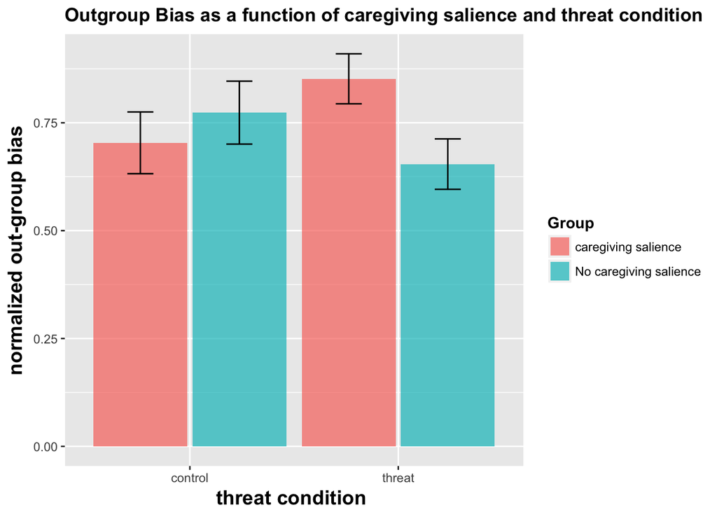

```r
limits = aes(ymax = mn + se, ymin=mn - se)

Fig1_plot = ggplot(Fig1, aes(x = factor(tnaythreat), y = mn, fill = factor(story)))+geom_bar(width=.9, stat = 'identity', position=position_dodge(.95),size=1.5,alpha = 0.7)+labs(title = "Outgroup Bias as a function of caregiving salience and threat condition", y="normalized out-group bias",x="threat condition ")+geom_errorbar(limits,color = 'black',position=position_dodge(.95),width=0.25) + labs(color = "Group") + theme(axis.title=element_text(face="bold",size="14", color="black")) + theme(title = element_text(face = "bold")) +  scale_fill_discrete("Group", labels = c("caregiving salience", "No caregiving salience"))
print(Fig1_plot)
```

The graph looks very close to what is graphically reported (Fig. 1) in the paper.